# MB5370_Module4 Assignment: Data Wrangling and Vizualization in R

Alan Thomas Joshy

2024-05-17

We will start by loading the necessary packages we think might be required for our data wrangling and analysis/visualization. In this case we shall start by loading “tidyverse”, which is a collection of useful R packages such as ‘ggplot2’, ‘tidyr’, ‘readr’, ‘tibble’, ‘dplyr’ among others.

```r
library(tidyverse)
```

Now we will load the CSV file containing the data which we want to visualize in a graph. In this case the data was obtained from the Queensland fisheries or QFISH website, which provides information on Queensland fisheries resources and spatial data sets (layers) using interactive tools, which we can view and download. The Department of Agriculture and Fisheries (DAF) is responsible for managing the Queensland Shark Control Program, which aims to reduce the chance of shark attacks on humans by removing large and potentially dangerous sharks from popular beaches along the Queensland Coastline. The data for the capture numbers by this program is available in the Qfish website (https://qfish.fisheries.qld.gov.au/query/number-caught-by-area-calendar-year-and-species-group/table) and we will be using the data for shark captures (no species distinction) in the respective regions from the years 2001 to 2024. The data from the website is downloaded as a .csv file, which we will load in using the following line of code and name it “dat”:

```r
dat <- read_csv("../data/Qfish data/qfish_shark.csv", na = c("N/A",""))
```

```
## ──────────────────────────────────────────────────────── Delimiter: "," chr
## (1): ...1 dbl (24): 2001, 2002, 2003, 2004, 2005, 2006, 2007, 2008, 2009, 2010,
## 2011, ... lgl (3): ...4, ...6, ...28
```

```r
dat
```

```
## # A tibble: 14 × 28
##    ...1      `2001` `2002` ...4  `2003` ...6  `2004` `2005` `2006` `2007` `2008`
##    <chr>      <dbl>  <dbl> <lgl>  <dbl> <lgl>  <dbl>  <dbl>  <dbl>  <dbl>  <dbl>
##  1 Bribie I…     NA     NA NA        NA NA        NA     NA     NA     NA     NA
##  2 Bundaberg     62     62 NA        50 NA        39     69     49     48     53
##  3 Cairns        79     46 NA        66 NA        62     66     41     76     55
##  4 Capricor…     87     91 NA        66 NA        80     84     68     81     69
##  5 Gladstone     32     18 NA        30 NA        51     40     54     49     52
##  6 Gold Coa…     85     73 NA        75 NA        75     78     38     35     34
##  7 Mackay       134     94 NA        82 NA       108     75     59     68     73
##  8 Nth Stra…     20     16 NA         8 NA         1      5     23     21     20
##  9 Rainbow …     35     31 NA        24 NA        26     39     67     49     49
## 10 Sunshine…     76     91 NA        56 NA        39     53     52     39     50
## 11 Sunshine…     NA     NA NA        NA NA        NA     NA     NA     NA     NA
## 12 Sunshine…     35     40 NA        35 NA        24     21     36     16     31
## 13 Townsvil…     89     59 NA        58 NA        76     90     92     73     99
## 14 Grand To…    734    621 NA       550 NA       581    620    579    555    585
## # ℹ 17 more variables: `2009` <dbl>, `2010` <dbl>, `2011` <dbl>, `2012` <dbl>,
## #   `2013` <dbl>, `2014` <dbl>, `2015` <dbl>, `2016` <dbl>, `2017` <dbl>,
## #   `2018` <dbl>, `2019` <dbl>, `2020` <dbl>, `2021` <dbl>, `2022` <dbl>,
## #   `2023` <dbl>, `2024` <dbl>, ...28 <lgl>
```

Now we have a tibble named “dat” which contains the data from 2001 to 2024 on the capture numbers of species of sharks deemed dangerous near popular Queensland beaches. We will need to do some data wrangling before we are able to visualize any of this data. The first thing we notice is that some columns do not have names and so r has assigned some numerical values to them. We have to rename these columns for ease of handling.

```r
#we named all the columns which were previously unnamed
names(dat)[names(dat) == "...1"] <- "Region"
names(dat)[names(dat) == "...4"] <- "col4"
names(dat)[names(dat) == "...6"] <- "col6"
names(dat)[names(dat) == "...28"] <- "col28"
dat
```

```
## # A tibble: 14 × 28
##    Region    `2001` `2002` col4  `2003` col6  `2004` `2005` `2006` `2007` `2008`
##    <chr>      <dbl>  <dbl> <lgl>  <dbl> <lgl>  <dbl>  <dbl>  <dbl>  <dbl>  <dbl>
##  1 Bribie I…     NA     NA NA        NA NA        NA     NA     NA     NA     NA
##  2 Bundaberg     62     62 NA        50 NA        39     69     49     48     53
##  3 Cairns        79     46 NA        66 NA        62     66     41     76     55
##  4 Capricor…     87     91 NA        66 NA        80     84     68     81     69
##  5 Gladstone     32     18 NA        30 NA        51     40     54     49     52
##  6 Gold Coa…     85     73 NA        75 NA        75     78     38     35     34
##  7 Mackay       134     94 NA        82 NA       108     75     59     68     73
##  8 Nth Stra…     20     16 NA         8 NA         1      5     23     21     20
##  9 Rainbow …     35     31 NA        24 NA        26     39     67     49     49
## 10 Sunshine…     76     91 NA        56 NA        39     53     52     39     50
## 11 Sunshine…     NA     NA NA        NA NA        NA     NA     NA     NA     NA
## 12 Sunshine…     35     40 NA        35 NA        24     21     36     16     31
## 13 Townsvil…     89     59 NA        58 NA        76     90     92     73     99
## 14 Grand To…    734    621 NA       550 NA       581    620    579    555    585
## # ℹ 17 more variables: `2009` <dbl>, `2010` <dbl>, `2011` <dbl>, `2012` <dbl>,
## #   `2013` <dbl>, `2014` <dbl>, `2015` <dbl>, `2016` <dbl>, `2017` <dbl>,
## #   `2018` <dbl>, `2019` <dbl>, `2020` <dbl>, `2021` <dbl>, `2022` <dbl>,
## #   `2023` <dbl>, `2024` <dbl>, col28 <lgl>
```

Now that all the columns have a name, we have to remove the empty columns. We name this new ‘data frame’ as “neodata”.

```r
#now we we'll remove the columns named col4 col6 and col28
neodata <- dat |> select(-col4, -col6 , -col28)
neodata
```

```
## # A tibble: 14 × 25
##    Region  `2001` `2002` `2003` `2004` `2005` `2006` `2007` `2008` `2009` `2010`
##    <chr>    <dbl>  <dbl>  <dbl>  <dbl>  <dbl>  <dbl>  <dbl>  <dbl>  <dbl>  <dbl>
##  1 Bribie…     NA     NA     NA     NA     NA     NA     NA     NA     NA     NA
##  2 Bundab…     62     62     50     39     69     49     48     53     30     42
##  3 Cairns      79     46     66     62     66     41     76     55     60     71
##  4 Capric…     87     91     66     80     84     68     81     69     60     65
##  5 Gladst…     32     18     30     51     40     54     49     52     63     57
##  6 Gold C…     85     73     75     75     78     38     35     34     37     39
##  7 Mackay     134     94     82    108     75     59     68     73     67     74
##  8 Nth St…     20     16      8      1      5     23     21     20     26     24
##  9 Rainbo…     35     31     24     26     39     67     49     49     59     51
## 10 Sunshi…     76     91     56     39     53     52     39     50     50     37
## 11 Sunshi…     NA     NA     NA     NA     NA     NA     NA     NA     NA     NA
## 12 Sunshi…     35     40     35     24     21     36     16     31     19     22
## 13 Townsv…     89     59     58     76     90     92     73     99    118    119
## 14 Grand …    734    621    550    581    620    579    555    585    589    601
## # ℹ 14 more variables: `2011` <dbl>, `2012` <dbl>, `2013` <dbl>, `2014` <dbl>,
## #   `2015` <dbl>, `2016` <dbl>, `2017` <dbl>, `2018` <dbl>, `2019` <dbl>,
## #   `2020` <dbl>, `2021` <dbl>, `2022` <dbl>, `2023` <dbl>, `2024` <dbl>
```

The next step is to change our data into ‘long’ format which R can easily visualize.

```r
newdata <- neodata |>
  pivot_longer(
    cols = starts_with("20"),
    names_to = "Year",
    values_to = "Captures"
  )

newdata
```

```
## # A tibble: 336 × 3
##    Region        Year  Captures
##    <chr>         <chr>    <dbl>
##  1 Bribie Island 2001        NA
##  2 Bribie Island 2002        NA
##  3 Bribie Island 2003        NA
##  4 Bribie Island 2004        NA
##  5 Bribie Island 2005        NA
##  6 Bribie Island 2006        NA
##  7 Bribie Island 2007        NA
##  8 Bribie Island 2008        NA
##  9 Bribie Island 2009        NA
## 10 Bribie Island 2010        NA
## # ℹ 326 more rows
```

I have noticed something in the data which needs to be tidied before we can visualize the data in an efficient manner. The data collected from the regions “Bribie Island” and “Sunshine Coast South”, before 2017 were recorded under one region and the data from 2017 to 2024 is available for the 2 distinct regions “Sunshine Coast South and Bribie Island”. We will merge the data for “Bribie Island” and “Sunshine Coast South” from 2017 to 2024, into “Sunshine Coast South and Bribie Island” to make visualization easier.

We will export the “newdata” tibble as an excel file to make wrangling it easier.

```r
#install.packages("writexl")

library(writexl)

#write_xlsx(newdata, "../data/Qfish data/newdata.xlsx")
```

In Microsoft Excel, I modified the data set by recording the sum of values for each year from 2017 to 2024 for “Bribie Island” and “Sunshine Coast South” for the region “Sunshine Coast South and Bribie Island”, and deleting the separate columns of “Bribie Island” and “Sunshine Coast South”. We then load the new data which was saved as an excel file named “newdata_combined.xlsx”

```r
library(readxl)

final_dat <- read_xlsx("../data/Qfish data/newdata_combined.xlsx")

final_dat
```

```
## # A tibble: 288 × 3
##    Region    Year  Captures
##    <chr>     <chr>    <dbl>
##  1 Bundaberg 2001        62
##  2 Bundaberg 2002        62
##  3 Bundaberg 2003        50
##  4 Bundaberg 2004        39
##  5 Bundaberg 2005        69
##  6 Bundaberg 2006        49
##  7 Bundaberg 2007        48
##  8 Bundaberg 2008        53
##  9 Bundaberg 2009        30
## 10 Bundaberg 2010        42
## # ℹ 278 more rows
```

We can now start visualizing this data set as it is in a format which makes data visualization very easy. Visualizing the data with ggplot:

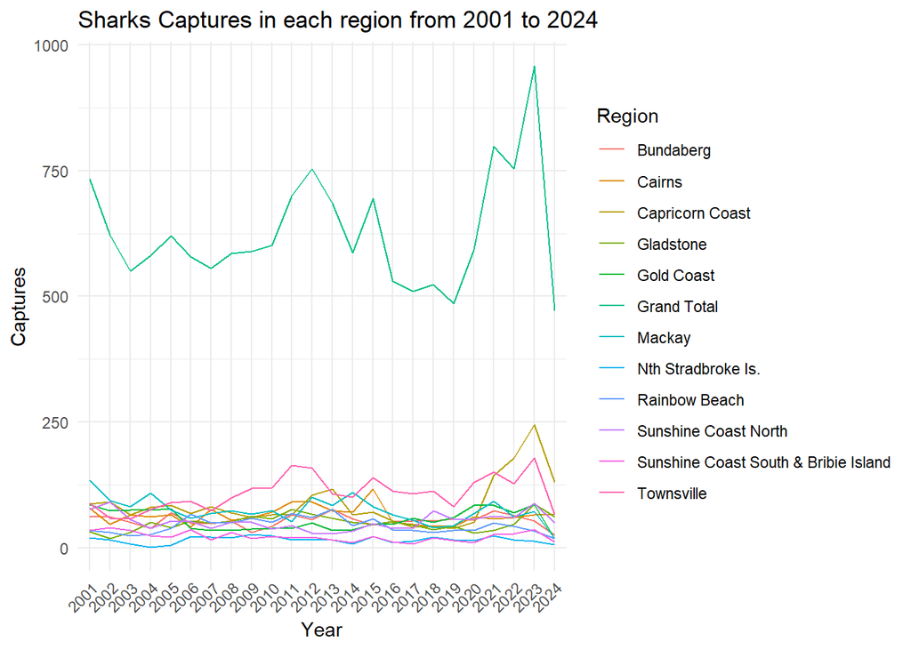

```r
plt <- ggplot2::ggplot(data = final_dat, aes(x = Year, y = Captures, colour = Region, group = Region)) +
  geom_line() +
  theme_minimal() +
  labs(title = "Sharks Captures in each region from 2001 to 2024", x = "Year", Y = "Captures") +
  theme(axis.text.x = element_text(angle = 45, hjust = 1))

plt
```

This is a good start if I say so myself ;), but let’s try to make a plot without including the line for “Grand Total”.

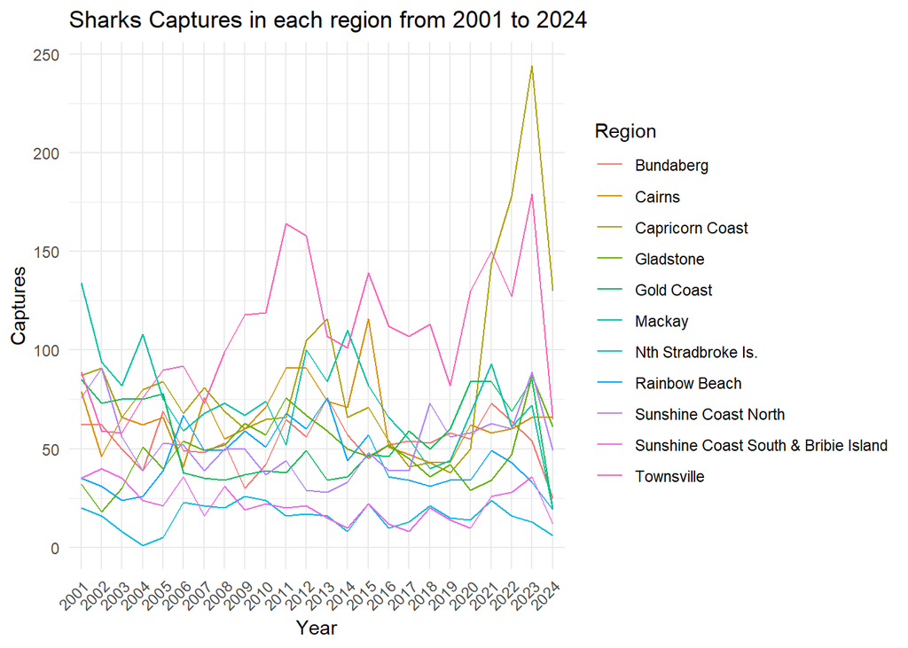

```r
fltrd_dta <- final_dat |> filter(Region != "Grand Total")

#plot graph with fltrd_dta
ggplot2::ggplot(data = fltrd_dta, aes(x = Year, y = Captures, colour = Region, group = Region)) +
  geom_line() +
  theme_minimal() +
  labs(title = "Sharks Captures in each region from 2001 to 2024", x = "Year", Y = "Captures") +
  theme(axis.text.x = element_text(angle = 45, hjust = 1))
```

We will also make a graph showing just the “Grand Total”.

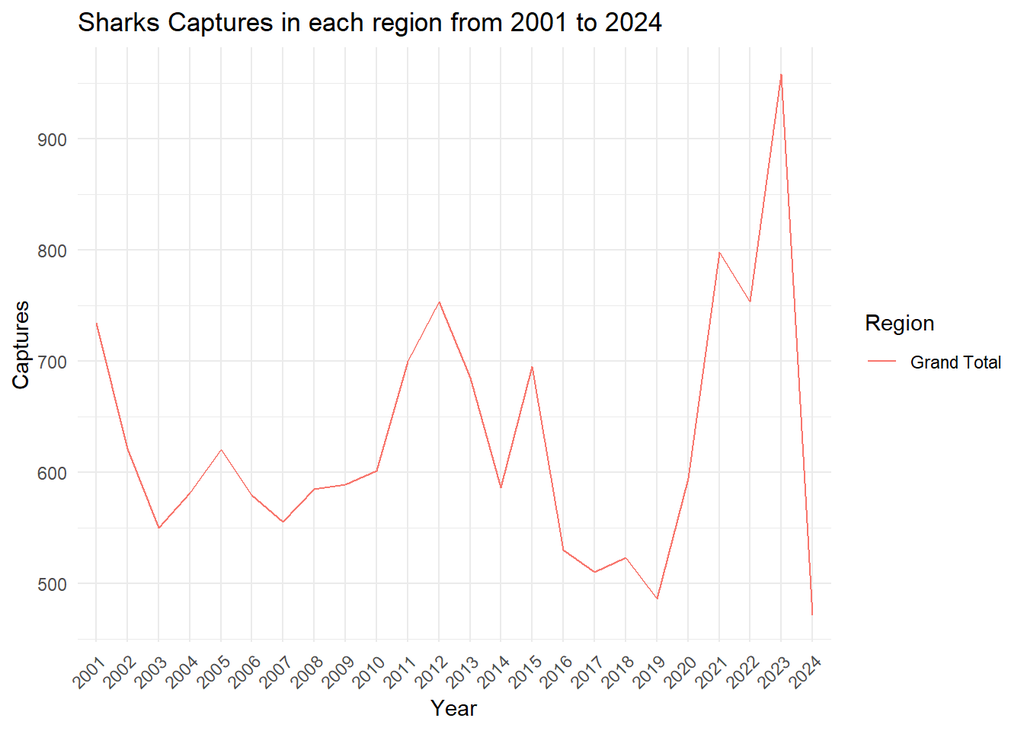

```r
grand_total <- final_dat |> filter(Region == "Grand Total")

#plot graph with grand_total
ggplot2::ggplot(data = grand_total, aes(x = Year, y = Captures, colour = Region, group = Region)) +
  geom_line() +
  theme_minimal() +
  labs(title = "Sharks Captures in each region from 2001 to 2024", x = "Year", Y = "Captures") +
  theme(axis.text.x = element_text(angle = 45, hjust = 1))
```

The graph is still ‘messy” looking due to the numerous lines corresponding to the different regions. I have decided to tidy up the visual aspect of the plot by ’logically’ grouping together some regions by proximity. I did this by exporting our “final_dat” data frame as an Excel file and modifying the excel file.

```r
#write_xlsx(final_dat, "../data/Qfish data/final_dat.xlsx")
```

The modified Excel file was saved as “NCS_regions.xlsx” and was loaded in as “com_data”

```r
com_data <- read_xlsx("../data/Qfish data/NCS_regions.xlsx", sheet = "NCS_regions")

com_data
```

```
## # A tibble: 72 × 3
##    Region    Year  Captures
##    <chr>     <chr>    <dbl>
##  1 North QLD 2001       302
##  2 North QLD 2002       199
##  3 North QLD 2003       206
##  4 North QLD 2004       246
##  5 North QLD 2005       231
##  6 North QLD 2006       192
##  7 North QLD 2007       217
##  8 North QLD 2008       227
##  9 North QLD 2009       245
## 10 North QLD 2010       264
## # ℹ 62 more rows
```

Please note that the division of North, Central and South Qld is only based on personal choices(into groups of 3 or 4 based on their geographical position away from the Equator) and do not follow any recognized distinctions existing in the state of Qld. In this case the Region of North QLD comprises the sum of data for the regions Cairns, Townsville and Mackay, Central QLD comprises the sum of data for the regions Capricorn Coast, Gladstone, Bundaberg and Rainbow Beach, and South QLD comprises the sum of data for the regions Sunshine Coast and Bribie Isl.,Gold Coast and North Stradbroke Isl.

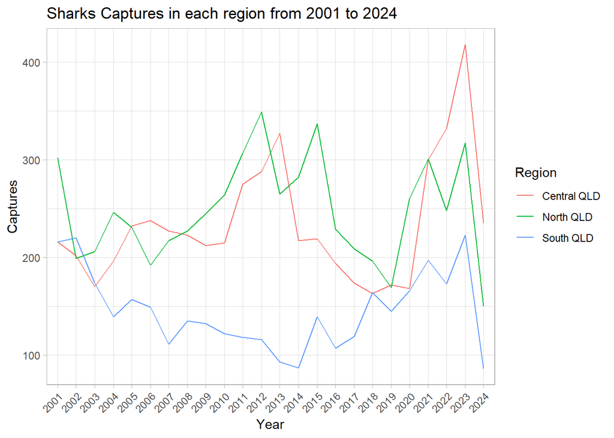

```r
#plot the Graph
ggplot2::ggplot(data = com_data, aes(x = Year, y = Captures, colour = Region, group = Region)) +
  geom_line() +
  theme_light() +
  labs(title = "Sharks Captures in each region from 2001 to 2024", x = "Year", Y = "Captures") +
  theme(axis.text.x = element_text(angle = 45, hjust = 1))
```